# MECH481A6: Engineering Data Analysis in R

Chapter 4 Homework: Visualizing Ozone Data

Genevieve Reyland-Slawson

19 September, 2023

*Note*: If you haven’t installed $LaTex$, change the output mode in the above YAML to `html_document` for ease of knitting and homework submission.

This R Markdown (.Rmd) file is a template for your Chapter 4 Homework. Do everything within this file. Make it your own, but be careful not to change the code-figure-text integration I set up with the code appendix and the global options. If you have used R Markdown before and are comfortable with the extra options, feel free to customize to your heart’s desire. In the end, we will grade the **knitted** PDF or HTML document from within your private GitHub repository. Remember to make regular, small commits (e.g., at least one commit per question) to save your work. We will grade the latest knit, as long as it occurs *before* the start of the class in which we advance to the next chapter. As always, reach out with questions via GitHub Issues or during office hours.

# Ozone data

The corresponding data file (.csv) contains *hourly* ozone data from two sites in Fort Collins. You should already have this file in your `/data` folder.

# Preparation

You completed the following steps in your Chapter 3 Homework. If correct, you should copy-paste the code into this R Markdown document; FYI, you cannot `source()` R Markdown files for use of its output in another file because they are intended to be self-contained and reproducible. Therefore, you need to copy-paste parts of your Chapter 3 Homework into this document and adjust the pathnames, if needed.

## Load R packages

```r
# load packages for current R session
library(tidyverse)
library(knitr)
```

## Import, select, and clean data

Recreate the pipe of `dplyr` functions that you used to import the data, select and rename the variables listed below, drop missing observations, and assign the output as a `tibble` (*not in that particular order*).

- `sample_measurement` renamed as `ozone_ppm` (ozone measurement in ppm)
- `datetime` (date in YYYY-MM-DD format and time of measurement in HH:MM:SS)

```r
# ozone: import, select, drop missing observations, rename
# Specify the relative path to the CSV file

csv_path <- "/Users/genevieve/Reyland-MECH476/data/ftc_o3.csv"

# Read the CSV file using the relative path
  ozone_data <- readr::read_csv(file = csv_path) %>%
    dplyr::select(sample_measurement,
                  datetime) %>%
    drop_na() %>%
    dplyr::rename(ozone_ppm = sample_measurement)
```

## Examine Data

Examine the structure and contents of the dataframe to confirm the file imported and was manipulated properly.

```r
# examine dataframe object
# examine tibble
glimpse(ozone_data)
```

```
## Rows: 16,914
## Columns: 2
## $ ozone_ppm <dbl> 0.017, 0.017, 0.017, 0.017, 0.015, 0.017, 0.028, 0.030, 0.03…
## $ datetime  <dttm> 2019-01-01 07:00:00, 2019-01-01 08:00:00, 2019-01-01 09:00:…
```

```r
# calculate number of missing observations
ozone_data_all <- readr::read_csv(file = csv_path)
ozone_data_drop <- sum(is.na(ozone_data_all$sample_measurement))
```

# Question 1: `ggplot2` time series

Using `ggplot` and the corresponding `geom`, create a time series of ozone measurement across time. Warning: This plot will have a very poor ink-to-information ratio. Ugly plots are okay when you are just exploring data.

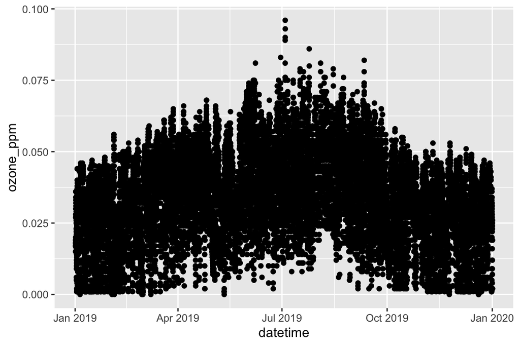

```r
# create basic time series using ggplot2 package
library(ggplot2)
ggplot(data = ozone_data) +
  geom_point(aes(x = datetime,
                 y = ozone_ppm))
```

# Question 2: Base R equivalent

For comparison, what function could you use to create a time series of these data in base R? How does the syntax of this function compare to that of `ggplot()`?

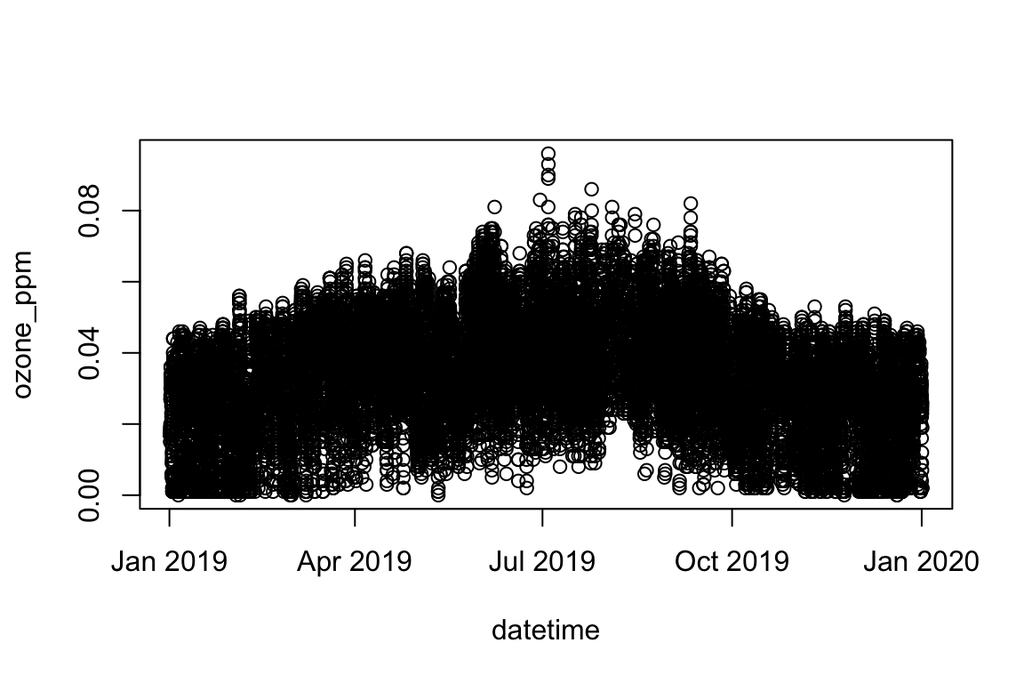

```r
plot(x = ozone_data$datetime,
     y = ozone_data$ozone_ppm,
     xlab = "datetime",
     ylab = "ozone_ppm")
```

# Question 3: `ggplot` object

Excluding the geom, assign the plot from Question 1 as a `ggplot` object with a descriptive name.

```r
# create base layer of ozone time series (no geom) and save to object
ozone_ggplot <- ggplot(ozone_data,
                          aes(x = datetime,
                              y = ozone_ppm))
```

# Question 4: `geom`

Now, `geom_point()` to the `ggplot` object using the following syntax: `object_name + geom_point()`. Remember, you have already defined the `aes()` in the `ggplot` object in Question 3.

```r
# add layer to ggplot object
ozone_ggplot <- ozone_ggplot + geom_point()
```

# Question 5: `ggplot` layers

Call and examine object within the R Markdown, Console, or using View. How many layers does this `ggplot` object contain? Why?

–> ggplot has 1 layer: geom point layer

# Question 6: theme

Next, add the `ggplot2` theme of your choice to the `ggplot` object with `theme_*()` function prefix.

```r
# add theme to ggplot object
ozone_ggplot <- ozone_ggplot + theme_classic()
```

# Question 7: additions

In addition to assigning a plot as a `ggplot` object, one can also assign aspects of the figure such as axis labels and titles to an object for later use. For example:

```r
# create new object with ggplot labels
ozone_labels <- labs(x = "Time of Measurement (YYYY-MM-DD HH:MM:SS)",
                     y = "Ozone Concentration (ppm)",
                     title = "Hourly Ozone Measurements in Fort Collins, CO")
```

Using this technique and the same additive approach (`ggplot_object + ... + title`) from Questions 5 and 6, add a title and revise the axis labels.

```r
# add title and axis labels to time series
ozone_ggplot <- ozone_ggplot + labs(x = "Date Time",
                                    y = "Ozone Concentration (ppm)",
                                    title = "Ozone Measurements in Fort Collins by Hour")
```

# Question 7: ways to see more granularity

The time series from the previous questions does not look nice. It is hard to discern granular patterns in the data because of their sheer density; there are too many hourly measurements over time. We could look at the data on different time scales, but, because we have not discussed how to manipulate dates and times, we will instead focus first on adding transparency to the data points using the `alpha =` aesthetic. Try recreating the time-series plot with `alpha = 0.2`.

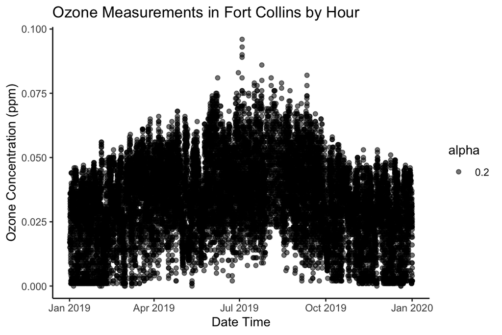

```r
# add alpha aesthetic to the geom_point()
ozone_ggplot <- ozone_ggplot + aes(alpha = 0.2)
ozone_ggplot
```

Alternatively, we could examine just the ozone measurements that exceed the threshold (0.070 ppm) set by the Environmental Protection Agency. Filter the dataset to the ozone levels exceeding 0.070 ppm, and use these data to construct a time series plot with time of measurement on the x-axis and ozone concentration measurement on the y-axis. Remember to add the relevant `geom`, title, subtitle, axis labels, and your choice of theme.

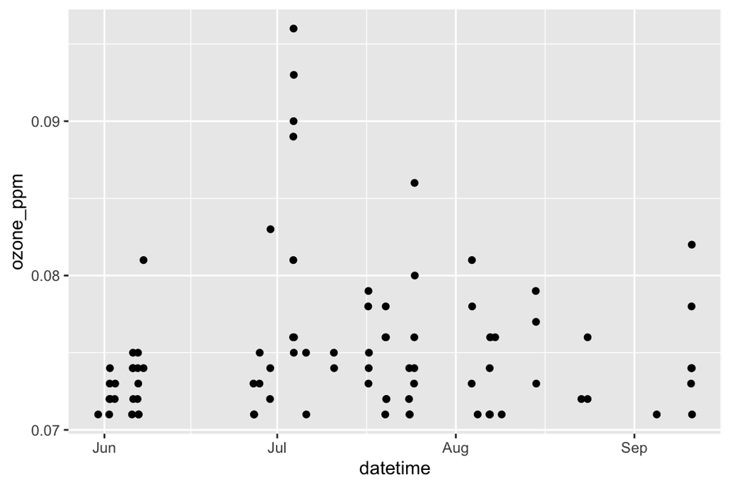

```r
# filter data to ozone concentration measurements exceeding 0.070 ppm
high_ozone <- filter(ozone_data, ozone_ppm > 0.070)

# time series of high ozone measurements
high_ozone_plot <- ggplot(high_ozone,
                          aes(x = datetime,
                              y = ozone_ppm)) +
                            geom_point()
high_ozone_plot
```

# Question 8: seasonality

Based on the time series, do you see any seasonal pattern for higher levels of ozone? Describe what you see.

–> a higher level of ozone occurs near the begining of July. This makes sense as this is peak summer time and most people are on vacation and traveling.

# Question 9: proportion

What proportion of ozone measurements exceed the EPA guidelines? Instead of plugging in the actual values, make R figure out the length of each vector and the corresponding proportion in one line of code.

```r
# calculate proportion of ozone measurements that exceed 0.070 ppm
ozone_perc <- (nrow(high_ozone) / nrow(ozone_data))*100
print(paste(round(ozone_perc, digits = 3), "% exceeding 0.070 ppm")) # rounded percentage of measurements that exceed 0.07 ppm
```

```
## [1] "0.503 % exceeding 0.070 ppm"
```

# Question 10: `ggplot2` extensions

Navigate to [this website](https://exts.ggplot2.tidyverse.org/gallery/) and browse the `ggplot2` extensions. These themes can be very useful, so it’s good to be aware of them. Which theme would be appropriate for your own research or senior project, and why? How would you use it? Briefly describe your data and why the extension would improve the data visualization and communication. –> ggaminate is a theme that could be beneficial for my senior design project. I am on a team that is developing a fully automated hydroponic greenhouse. This greenhouse will be monitoring levels of nutrient through EC sensors as well as other sensors for pH, water pressure, and sunlight. All of these could benefit from ggaminate as it would be able to show the user (there will be a user screen to help the user see how the crops are doing and the levels of water, nutrient, light, and other specs) a visual for the specs predetermined over time.

# Appendix

```r
# set global options for figures, code, warnings, and messages
knitr::opts_chunk$set(fig.width = 6, fig.height = 4, fig.path = "../figs/",
                      echo = TRUE, warning = FALSE, message = FALSE)
# load packages for current R session
library(tidyverse)
library(knitr)
# ozone: import, select, drop missing observations, rename
# Specify the relative path to the CSV file

csv_path <- "/Users/genevieve/Reyland-MECH476/data/ftc_o3.csv"

# Read the CSV file using the relative path
  ozone_data <- readr::read_csv(file = csv_path) %>%
    dplyr::select(sample_measurement,
                  datetime) %>%
    drop_na() %>%
    dplyr::rename(ozone_ppm = sample_measurement)
# examine dataframe object
# examine tibble
glimpse(ozone_data)

# calculate number of missing observations
ozone_data_all <- readr::read_csv(file = csv_path)
ozone_data_drop <- sum(is.na(ozone_data_all$sample_measurement))
# create basic time series using ggplot2 package
library(ggplot2)
ggplot(data = ozone_data) +
  geom_point(aes(x = datetime,
                 y = ozone_ppm))
plot(x = ozone_data$datetime,
     y = ozone_data$ozone_ppm,
     xlab = "datetime",
     ylab = "ozone_ppm")
# create base layer of ozone time series (no geom) and save to object
ozone_ggplot <- ggplot(ozone_data,
                          aes(x = datetime,
                              y = ozone_ppm))
# add layer to ggplot object
ozone_ggplot <- ozone_ggplot + geom_point()
# add theme to ggplot object
ozone_ggplot <- ozone_ggplot + theme_classic()
# create new object with ggplot labels
ozone_labels <- labs(x = "Time of Measurement (YYYY-MM-DD HH:MM:SS)",
                     y = "Ozone Concentration (ppm)",
                     title = "Hourly Ozone Measurements in Fort Collins, CO")
# add title and axis labels to time series
ozone_ggplot <- ozone_ggplot + labs(x = "Date Time",
                                    y = "Ozone Concentration (ppm)",
                                    title = "Ozone Measurements in Fort Collins by Hour")
# add alpha aesthetic to the geom_point()
ozone_ggplot <- ozone_ggplot + aes(alpha = 0.2)
ozone_ggplot
# filter data to ozone concentration measurements exceeding 0.070 ppm
high_ozone <- filter(ozone_data, ozone_ppm > 0.070)

# time series of high ozone measurements
high_ozone_plot <- ggplot(high_ozone,
                          aes(x = datetime,
                              y = ozone_ppm)) +
                            geom_point()
high_ozone_plot
# calculate proportion of ozone measurements that exceed 0.070 ppm
ozone_perc <- (nrow(high_ozone) / nrow(ozone_data))*100
print(paste(round(ozone_perc, digits = 3), "% exceeding 0.070 ppm")) # rounded percentage of measurements that exceed 0.07 ppm
```